# Brain dump: phylogenetic comparative methods in the lme4-verse

Ben Bolker

13:07 07 June 2017

```r
library(ape)
library(lme4)
library(Matrix)
## additional possibilities for PGLMMs ...
library(MCMCglmm)
library(lattice)
library(pez)
## utils
library(coda)
library(broom)
library(dotwhisker)
```

- The standard problem of *phylogenetic comparative methods* is to analyze relationships among data where the observations are gathered from nodes (usually tips) of a phylogenetic tree - for example, regression analyses of body temperature as a function of body size for animals within a clade
- More generally, we can frame this in the usual GLMM way as
  $$\begin{split}
  y & \sim D(\mu,\phi) \\
  \mu & = g^{-1}(\eta) = g^{-1}(X \beta + Z b) \\
  b & \sim \textrm{MVN}(0,\Sigma)
  \end{split}$$
  where the part that makes it specifically phylogenetic is that $\Sigma$ captures the *phylogenetic correlation*. The PC is the correlation among observations due to relatedness; recently diverged taxa have higher correlation than more anciently diverged taxa. In the extreme case of a *star phylogeny* (all taxa diverged from each other simultaneously at some point in the past) the phylogenetic correlation collapses to a diagonal matrix and we get back to the simple, uncorrelated regression.

Various P(G)LMM (phylogenetic [generalized] linear mixed model] approaches have been proposed. Many depend on Pagel’s lambda transformation, which gives the correlation matrix a particularly simple form (but has been [criticized](http://www.carlboettiger.info/2013/10/11/is-it-time-to-retire-pagels-lambda.html) …)

An alternative approach is to model the phylogenetic correlation as a *Gaussian process*. In particular, suppose that the evolutionary process is a Brownian motion (an almost certainly incorrect/oversimplified model of evolution, but one that many phylogenetic methods are built on). In that case, the phylogenetic variability of a particular observation can be written as the sum of the evolutionary changes that occurred on all of the branches in the phylogeny in its past. If we set up the $Z$ matrix appropriately, we can model everything with a sequence of *independent* errors, rather than having to do fancy things to impose a correlation structure on the random effects.

## Nuts and bolts: from a phylogeny to a $Z$ matrix for the GP

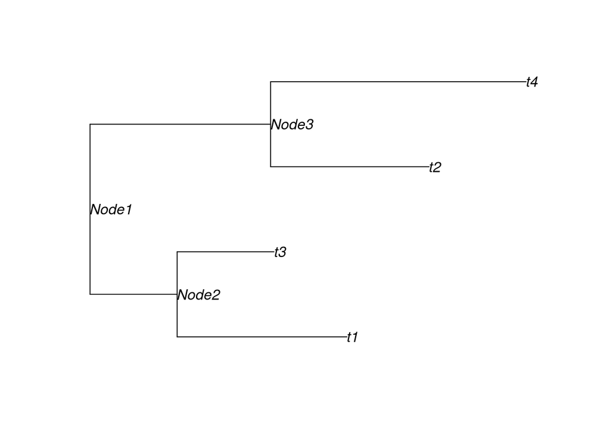

```r
library(ape)
set.seed(101)
r <- makeNodeLabel(rtree(4))
plot(r,show.node.label=TRUE)
```

Information in a `phylo` object is contained in the *edge matrix*:

> edge: a two-column matrix of mode numeric where each row represents an edge of the tree; the nodes and the tips are symbolized with numbers; the tips are numbered 1, 2, …, and the nodes are numbered after the tips. For each row, the first column gives the ancestor.

```r
t(r$edge)
```

```
##      [,1] [,2] [,3] [,4] [,5] [,6]
## [1,]    5    6    6    5    7    7
## [2,]    6    1    2    7    3    4
```

and a list of *edge lengths*

```r
r$edge.length
```

```
## [1] 0.3000548 0.5848666 0.3334671 0.6220120 0.5458286 0.8797957
```

Inspecting this tree, we can figure out (see `$tip.label` and `$node.label` for label-to-number correspondences):

- tips are 1-4, nodes are 5-7
- tip 1 (`t1`) involves branches 2 (6 $\to$ 1) and 1 (5 $\to$ 6).
- tip 2 (`t3`) involves branches 3 (6 $\to$ 2) and 1 (5 $\to$ 6)
- tip 3 (`t2`) involves branches 5 (7 $\to$ 3) and 4 (5 $\to$ 7)
- tip 4 (`t4`) involves branches 6 (7 $\to$ 4) and 4 (5 $\to$ 7)

So, for example, we can say that the ‘error’ value corresponding to tip 1 is $\ell_1 b_1 + \ell_2 b_2$, where $\ell_i$ is the (square root of??) the branch length and the $b_i$ are independent, homoscedastic Normal variates. Alternately, the $Z$ matrix is

$$\begin{pmatrix}
\ell_1 & \ell_2 & 0 & 0 & 0 & 0 \\
\ell_1 & 0 & \ell_3 & 0 & 0 & 0 \\
0 & 0 & 0 & \ell_4 & \ell_5 & 0 \\
0 & 0 & 0 & \ell_4 & 0 & \ell_6
\end{pmatrix}$$
where $\ell_i$ is the length of the $i^\textrm{th}$ branch, so that the species effects are $Z b$.

If we can build the corresponding $Z$ matrix, then we can insert it in the `lme4` modular model-fitting process (see `?modular`).

Here’s a (probably not very efficent) way to construct the Z matrix. (There must be a way to not walk the tree multiple times from every tip …

```r
phylo.to.Z <- function(r) {
    ntip <- length(r$tip.label)
    Z <- Matrix(0.0,ncol=length(r$edge.length),nrow=ntip)
    nodes <- (ntip+1):max(r$edge)
    root <- nodes[!(nodes %in% r$edge[,2])]
    for (i in 1:ntip) {
        cn <- i  ## current node
        while (cn != root) {
            ce <- which(r$edge[,2]==cn)   ## find current edge
            Z[i,ce] <- r$edge.length[ce]  ## set Z to branch length
            cn <- r$edge[ce,1]            ## find previous node
        }
    }
    return(Z)
}
phylo.to.Z(r)
```

```
## 4 x 6 sparse Matrix of class "dgCMatrix"
##
## [1,] 0.3000548 0.5848666 .         .        .         .
## [2,] 0.3000548 .         0.3334671 .        .         .
## [3,] .         .         .         0.622012 0.5458286 .
## [4,] .         .         .         0.622012 .         0.8797957
```

(This could benefit from the repeated-entry sparse matrix class that Steve Walker wrote.)

On the other hand, it only takes a few seconds to run for a 200-species phylogeny (see below).

## constructing a GP PGLMM

“All” we need to do is (1) call `(g)lFormula`, with a formula that includes a `(1|phylo)` term, to build the basic (wrong) structure; (2) modify the `reTrms` component of the structure appropriately; (3) go through the rest of the modular procedure for building a (G)LMM.

```r
#' split a square (block) matrix into component blocks
#' @param M square matrix
#' @param ind indices (0,n1,n2,...) giving the endpoint of each block
split_blkMat <- function(M,ind) {
    res <- list()
    if (length(ind)==1) return(list(M))
    for (i in 1:(length(ind)-1)) {
        v <- (ind[i]+1):ind[i+1]
        res[[i]] <- M[v,v]
    }
    return(res)
}

#' modify reTrms object
#' @param rt a reTrms object
#' @param phylo a phylo object (phylogenetic tree)
#' @param phylonm name of phylogenetic term in model
#' @param phyloZ Z matrix built on branch length
modify_phylo_retrms <- function(rt,phylo,phylonm="phylo",
                                phyloZ=phylo.to.Z(phylo)) {
    ## FIXME: better way to specify phylonm
    ## need to replace Zt, Lind, Gp, flist, Ztlist
    ## we have the same number of parameters (theta, lower),
    ##  same number of obs
    n.edge <- nrow(phylo$edge)
    phylo.pos <- which(names(rt$cnms)==phylonm)
    inds <- c(0,cumsum(sapply(rt$Ztlist,nrow)))
    ## Zt: substitute phylo Z for previous dummy (scalar-intercept) Z
    rt[["Ztlist"]][[phylo.pos]] <- t(phyloZ)
    ## reconstitute Zt from new Ztlist
    rt[["Zt"]] <- do.call(rbind,rt[["Ztlist"]])
    ## Gp: substitute new # random effects (n.edge) for old # (n.phylo)
    Gpdiff <- diff(rt$Gp)  ## old numbers
    Gpdiff_new <- Gpdiff
    Gpdiff_new[phylo.pos] <- n.edge  ## replace
    rt[["Gp"]] <- as.integer(c(0,cumsum(Gpdiff_new)))          ## reconstitute
    ## Lind: replace phylo block with the same element, just more values
    Lind_list <- split(rt[["Lind"]],rep(seq_along(Gpdiff),Gpdiff))
    Lind_list[[phylo.pos]] <- rep(Lind_list[[phylo.pos]][1],n.edge)
    rt[["Lind"]] <- unlist(Lind_list)
    ## Lambdat: replace block-diagonal element in Lambdat with a
    ##   larger diagonal matrix
    Lambdat_list <- split_blkMat(rt[["Lambdat"]],inds)
    Lambdat_list[[phylo.pos]] <- Diagonal(n.edge,1.0)
    rt[["Lambdat"]] <- Matrix::.bdiag(Lambdat_list)
    ## flist:
    rt[["flist"]] <- as.list(rt[["flist"]])
    rt[["flist"]][[phylonm]] <- factor(paste0("edge_",seq(n.edge)))
    return(rt)
}

#'
phylo_glmm <- function(formula,data,family,phylo,phyloZ) {
    glmod <- glFormula(formula=formula,data = data, family = family)
    glmod$reTrms <- modify_phylo_retrms(glmod$reTrms,phylo,
                                        phylonm="phylo",phyloZ)
    devfun <- do.call(mkGlmerDevfun, glmod)
    opt <- optimizeGlmer(devfun)
    devfun <- updateGlmerDevfun(devfun, glmod$reTrms)
    opt <- optimizeGlmer(devfun, stage=2)
    mkMerMod(environment(devfun), opt, glmod$reTrms, fr = glmod$fr)
}
```

## example

From [chapter 11](http://www.mpcm-evolution.org/practice/online-practical-material-chapter-11/chapter-11-1-simple-model-mcmcglmm) of Garamszegi (ed.): data are [here](http://mpcm-evolution.org/OPM/Chapter11_OPM/data.zip)

```r
if (!file.exists("data/phylo.nex")) {
    dir.create("data")
    download.file("http://mpcm-evolution.org/OPM/Chapter11_OPM/data.zip",
                  dest="data/OPM_ch11_data.zip")
    setwd("data")
    untar("OPM_ch11_data.zip")
    setwd("..")
}
phylo <- read.nexus("data/phylo.nex")
dat <- read.table("data/data_pois.txt",header=TRUE)
```

```r
system.time(phyloZ <- phylo.to.Z(phylo))
```

```
##    user  system elapsed
##   5.276   0.012   5.312
```

Add an observation-level random effect (in case we want to match with `MCMCglmm`)

```r
dat$obs <- factor(seq(nrow(dat)))
phylo_glmm_fit <- phylo_glmm(phen_pois~cofactor+(1|phylo)+(1|obs),
                             data=dat,family=poisson,phylo=phylo,
                             phyloZ=phyloZ)
```

From Garamszegi ch. 11 code examples.

```r
nitt <- 5e5 ## was 5e6
inv.phylo <- inverseA(phylo,nodes="TIPS",scale=TRUE)
prior <- list(G=list(G1=list(V=1,nu=0.02)),R=list(V=1,nu=0.02))
MCMC_time <- system.time(
    MCMCglmm_fit <- MCMCglmm(phen_pois~cofactor,random=~phylo,
                       family="poisson",ginverse=list(phylo=inv.phylo$Ainv),
                       prior=prior,data=dat,nitt=nitt,burnin=1000,
                       thin=nitt/1000,verbose=FALSE))
```

`MCMCglmm` fit takes about 28 minutes … effective sample size is 1000, which means the initial suggested 5 million steps may be overkill ? (However, with only 5e4 parameter sets we get wonky-looking trace plots/effective sample size of only 200, so 5e5 may be necessary …)

```r
ss <- summary(MCMCglmm_fit)
with(ss,rbind(solutions[,1:3],Gcovariances[,1:3],Rcovariances[,1:3]))
```

```
##               post.mean     l-95% CI   u-95% CI
## (Intercept) -2.08796523 -2.479168010 -1.6785878
## cofactor     0.25082309  0.229117489  0.2738551
##              0.03959840  0.002052013  0.1047885
##              0.04294357  0.003287147  0.1029546
```

```r
rbind(coef(summary(phylo_glmm_fit))[,1:2],
      cbind(matrix(unlist(VarCorr(phylo_glmm_fit))),NA))
```

```
##                Estimate Std. Error
## (Intercept) -2.09051239 0.18813499
## cofactor     0.25032657 0.01117239
##              0.05177132         NA
##              0.04132941         NA
```

Not exactly identical, but pretty close (priors, etc. etc.) (Getting profile confidence intervals will take some more work, because we can’t use `update.merMod` transparently within the profile …)

## To do

- Update the `tidy` method for `MCMCglmm_fit` to return the standard devs …
- Think about connections to/correspondence with Pagel’s $\lambda$, which multiplies the phylogenetic covariance matrix by a factor $0<\lambda<1$?
- In an LMM what assumptions do we have to make about residual var, i.e. fix it to a small value?
- When is residual var unidentifiable (e.g. all terminal branch lengths identical)?
- how easy is it to put this into `glmmTMB`?
- how easily could we implement an O-U process (this would require that Z be recomputed each time with changing $\alpha$ [and reference level]: could be considerably more difficult/mess up some of the linear algebra tricks?)